# 512hw4

Jieyi Sun

2022/3/28

## problem 1.

The largest value of AUC: $1-(1-\beta)*(1-\alpha)$

The smallest value of AUC: $0.5+0.5*(\alpha-1+\beta)^2$

## problem 2.

We’ll use the MNIST image classification data, available as mnist_all.RData. For this problem we want to distinguish between 1 and 3. Filter the train data to only include digits 1 and 3. Remove all variables (pixels) that have zero variance, i.e. pixels that have the same value for both digits. Repeat this for the test data. It’s recommended to write a function that you can run on both datasets. In this problem, you will do two forward selection steps for finding good logistic models.

```r
library(tidyverse)
library(dslabs)
library(pROC)
library(caret)
mnist <- read_mnist()
```

```r
index.13.train <- mnist$train$labels == 1 | mnist$train$labels == 3
train.13 <- as.data.frame(mnist$train$images[index.13.train,])
train.13$label <- as.numeric(mnist$train$labels[index.13.train]==1)

index.13.test <- mnist$test$labels == 1 | mnist$test$labels == 3
test.13 <- as.data.frame(mnist$test$images[index.13.test,])
test.13$label <- as.numeric(mnist$test$labels[index.13.test]==1)
```

```r
train.13=train.13[,-nearZeroVar(train.13)]
test.13= train.13[,colnames(train.13)]
```

Part a

```r
library(MASS)
find_pixel= function(){
  results=data.frame()
  for(i in 1:(ncol(train.13)-1)){
    full.model= glm(label~train.13[,i], family=binomial,data=train.13)
    prob = predict(full.model, newdata = as.data.frame(train.13[,c(i,189)]), type = "response")
    roc = roc(train.13$label ~ prob,quiet = TRUE)
    results[i,'pixel']= colnames(train.13)[i]
    results[i,'auc']= as.numeric(roc$auc)
  }
  return(results)
}
results= find_pixel()
results[which.max(results$auc),]
```

```
##     pixel       auc
## 112  V490 0.9438168
```

```r
# V490 is at the column 112, giving the best logistical model, with auc value of 0.9438168
```

Part b

```r
#The best pixel I found in part a: V490 is at the column 112
find_onemore_pixel= function(){
  results=data.frame()
  for(i in c(1:111,113:(ncol(train.13)-1))){
    newdf= as.data.frame(train.13[,c(i,112,189)])
    full.model= glm(label~., family=binomial,data=newdf)
    prob = predict(full.model, newdata = newdf, type = "response")
    roc = roc(train.13$label ~ prob,quiet = TRUE)
    results[i,'one_more_pixel']= colnames(train.13)[i]
    results[i,'auc']= as.numeric(roc$auc)
  }
  return(results)
}
results= find_onemore_pixel()
results[which.max(results$auc),]
```

```
##     one_more_pixel      auc
## 117           V495 0.974748
```

V495 is at the row 117, with auc value of 0.9747480.

Part c

```r
# model 1
training_1 = data.frame(train.13[,c('V490','label')])
colnames(training_1)=c("V490","label")

model_1= glm(label~V490, family=binomial,data=training_1)

prob = predict(model_1, newdata = data.frame(V490= test.13$V490),type = "response")

roc = roc(test.13$label ~ prob,quiet = TRUE)
auc_1 = roc$auc
auc_1 # 0.9438
```

```
## Area under the curve: 0.9438
```

```r
#model 2
training_2=as.data.frame(train.13[,c('V490','V495','label')])
colnames(training_2)=c("V490","V495","label")

model_2= glm(label~V490+V495, family=binomial,data=training_2)

prob = predict(model_2, newdata = data.frame(V490= test.13$V490,V495=test.13$V495), type = "response")

roc = roc(test.13$label ~ prob,quiet = TRUE)

auc_2 = roc$auc
auc_2 #0.9747
```

```
## Area under the curve: 0.9747
```

auc_2 is greater than auc_1, so the second model is really better than the first one.

Part d (188+187) models have been examined. (188+187+186…+179) models will be examined if I want to find the best logistic model with 10 pixels.

## Problem 3

```r
library(tidyverse)
library(dslabs)
library(pROC)
library(caret)
```

```r
mnist <- read_mnist()

index.47.train <- mnist$train$labels == 4 | mnist$train$labels == 7
train.47 <- as.data.frame(mnist$train$images[index.47.train,])
train.47$label <- as.numeric(mnist$train$labels[index.47.train]==4)

index.47.test <- mnist$test$labels == 4 | mnist$test$labels == 7
test.47 <- as.data.frame(mnist$test$images[index.47.test,])
test.47$label <- as.numeric(mnist$test$labels[index.47.test]==4)
```

Part a

```r
train.var = apply(train.47[,1:784],2,FUN = sd)
train.order =  order(train.var, decreasing = T)
head(train.order, 2) #V430, V402
```

```
## [1] 430 402
```

```r
model = glm(label~V430+V402,family = binomial, data = train.47)
prob = predict(model, newdata = train.47, type = "response")
roc = roc(train.47$label~prob, quiet = TRUE)
roc$auc #0.9252
```

```
## Area under the curve: 0.9252
```

Part b

```r
library(nnet)
test=data.frame(V430= test.47$V430,V402=test.47$V402,label=test.47$label)
net1 <- nnet(label~V430+V402, data = train.47, size = 1, decay = .001, maxit = 1000, linout = F)
prob = predict(net1, newdata = train.47, type = "r")
roc = roc(train.47$label~prob, quiet = TRUE)
roc$auc #0.926 The result is very close to part a because we only use one hidden layer.
```

```
## Area under the curve: 0.926
```

Part c

```r
test=data.frame(V402= test.47$V402,V430=test.47$V430,label=test.47$label)
net10 <- nnet(label~V402+V430, data = train.47, size = 10, decay = .001, maxit = 1000, linout = F)
prob = predict(net10, newdata = train.47,type = "r")

roc = roc(train.47$label~prob, quiet = TRUE)
roc$auc #0.9274
```

```
## Area under the curve: 0.927
```

```r
net20 <- nnet(label~V402+V430, data = train.47, size = 20, decay = .001, maxit = 1000, linout = F)
prob = predict(net20,newdata = train.47, type = "r")
roc = roc(train.47$label~prob, quiet = TRUE)
roc$auc #0.9284
```

```
## Area under the curve: 0.9281
```

```r
net30 <- nnet(label~V402+V430, data = train.47, size = 30, decay = .001, maxit = 1000, linout = F)
prob = predict(net30, newdata = train.47,type = "r")

roc = roc(train.47$label~prob, quiet = TRUE)
roc$auc #0.9271
```

```
## Area under the curve: 0.9289
```

## Problem 4

Part a

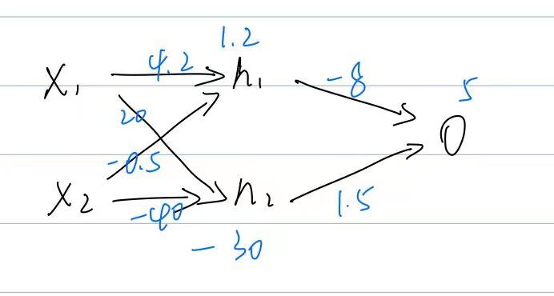

Part b $h1 = tanh(4.2*X1-0.5*X2+1.2)$ $h2 = tanh(20*X1-40*X2-30)$

Part c $z=tanh(-8*h1+1.5*h2+5)$

## Problem 5

```r
library(MASS)
data("Boston")
data = Boston
data[data$crim>median(data$crim),'high_crim']=1
data[data$crim<=median(data$crim),'high_crim']=0
set.seed(123)
cv_10 = trainControl(method = "cv", number = 10, savePredictions = TRUE)
```

part a: Logistic regression method

```r
library(tidyverse)
library(caret)
glm.fit = train(factor(high_crim)~., data = data, method = "glm", family = "binomial", trControl = cv_10)
summary(glm.fit)
```

```
##
## Call:
## NULL
##
## Deviance Residuals:
##        Min          1Q      Median          3Q         Max
## -2.584e-03  -2.000e-08   0.000e+00   2.000e-08   2.655e-03
##
## Coefficients:
##               Estimate Std. Error z value Pr(>|z|)
## (Intercept) -1.437e+01  1.202e+05   0.000    1.000
## crim         1.083e+03  1.773e+04   0.061    0.951
## zn           2.194e+00  5.856e+01   0.037    0.970
## indus       -2.510e+00  9.002e+02  -0.003    0.998
## chas         4.489e+00  1.014e+04   0.000    1.000
## nox         -2.585e+02  1.458e+05  -0.002    0.999
## rm          -3.953e+01  1.653e+03  -0.024    0.981
## age          3.437e-01  5.798e+01   0.006    0.995
## dis         -1.742e+01  2.146e+03  -0.008    0.994
## rad         -5.933e+00  2.642e+03  -0.002    0.998
## tax          1.639e-01  1.078e+02   0.002    0.999
## ptratio      5.525e+00  3.640e+03   0.002    0.999
## black        3.266e-02  1.208e+01   0.003    0.998
## lstat       -1.687e+00  3.560e+02  -0.005    0.996
## medv         2.358e+00  5.382e+02   0.004    0.997
##
## (Dispersion parameter for binomial family taken to be 1)
##
##     Null deviance: 7.0146e+02  on 505  degrees of freedom
## Residual deviance: 2.8371e-05  on 491  degrees of freedom
## AIC: 30
##
## Number of Fisher Scoring iterations: 25
```

Part b: LDA method

```r
lda.fit = train(factor(high_crim)~., data = data, method = "lda", trControl = cv_10)
summary(lda.fit)
```

```
##             Length Class      Mode
## prior        2     -none-     numeric
## counts       2     -none-     numeric
## means       28     -none-     numeric
## scaling     14     -none-     numeric
## lev          2     -none-     character
## svd          1     -none-     numeric
## N            1     -none-     numeric
## call         3     -none-     call
## xNames      14     -none-     character
## problemType  1     -none-     character
## tuneValue    1     data.frame list
## obsLevels    2     -none-     character
## param        0     -none-     list
```

Part c: QDA method

```r
qda.fit = train(factor(high_crim)~., data = data, method = "qda", trControl = cv_10)
summary(qda.fit)
```

```
##             Length Class      Mode
## prior         2    -none-     numeric
## counts        2    -none-     numeric
## means        28    -none-     numeric
## scaling     392    -none-     numeric
## ldet          2    -none-     numeric
## lev           2    -none-     character
## N             1    -none-     numeric
## call          3    -none-     call
## xNames       14    -none-     character
## problemType   1    -none-     character
## tuneValue     1    data.frame list
## obsLevels     2    -none-     character
## param         0    -none-     list
```

Part d

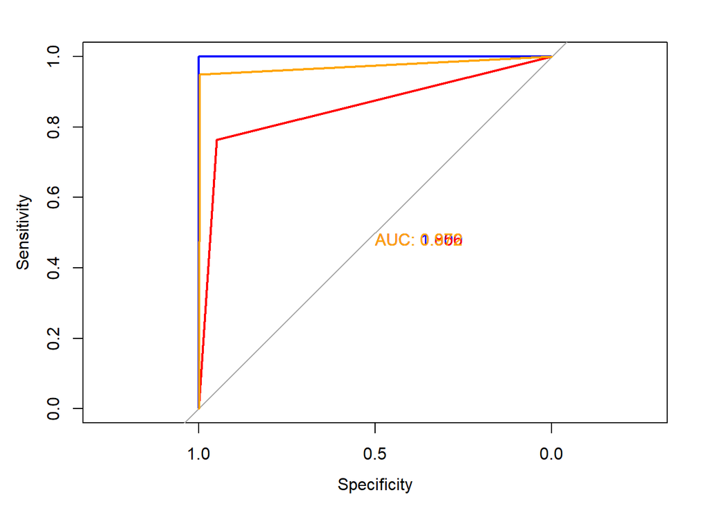

```r
library(ggplot2)
# make predictions
glm.pred = predict(glm.fit, newdata = data, ype = 'raw')
lda.pred = predict(lda.fit, newdata = data, )
qda.pred = predict(qda.fit, newdata = data, )

# ROC
roc.glm = roc(data$high_crim~as.numeric(glm.pred), plot = TRUE, print.auc = TRUE, col = 'blue')
roc.lda = roc(data$high_crim~as.numeric(lda.pred), plot = TRUE, print.auc = TRUE, col = 'red', add = TRUE)
roc.qda = roc(data$high_crim~as.numeric(qda.pred), plot = TRUE, print.auc = TRUE, col = 'orange', add = TRUE)
```

```r
as.numeric(roc.glm$auc)
```

```
## [1] 1
```

```r
as.numeric(roc.lda$auc)
```

```
## [1] 0.8557312
```

```r
as.numeric(roc.qda$auc)
```

```
## [1] 0.972332
```

Comparing the auc value, I chose Logistic regression method which has the largest AUC.

## Problem 6

Part a. linear Bayes decision boundary QDA has better performance on the training set. Its higher flexibility can generate a closer fit. But QDA tend to overfit the linearity on the Bayes decision bondary. So we chose LDA when fitting on the test set.

Part b. non-linear Bayes decision boundary I will chose QDA for both training and test sets. Unlike LDA, QDA assumes that each class has its own covariance matrix.

Part c. QDA will have better performance because greater sample size gives more flexibility. So we expect the test prediction accuracy of QDA relative to LDA to improve.

Part d. False If the sample size is linear, QDA tend to lead to overfit.